# UCI_CreditCard_PredictionModel

```r
#install.packages("dplyr")
#install.packages("lattice")
#install.packages("caret")
#install.packages("DMwR")
#install.packages("corrplot")
library(dplyr)
library(lattice)
library(caret)
library(DMwR)
library(corrplot)
library(randomForest)
library(yardstick)
library(pROC)
library(ROCR)
library(InformationValue)
```

## Reading the csv file

```r
setwd("D:/UCI_Credit_Card.csv")
UCI_Credit_Card <- read.csv("UCI_Credit_Card.csv",sep=',',header=TRUE)
glimpse(UCI_Credit_Card)
```

```
## Rows: 30,000
## Columns: 25
## $ ID                         <int> 1, 2, 3, 4, 5, 6, 7, 8, 9, 10, 11, 12, 1...
## $ LIMIT_BAL                  <dbl> 20000, 120000, 90000, 50000, 50000, 5000...
## $ SEX                        <int> 2, 2, 2, 2, 1, 1, 1, 2, 2, 1, 2, 2, 2, 1...
## $ EDUCATION                  <int> 2, 2, 2, 2, 2, 1, 1, 2, 3, 3, 3, 1, 2, 2...
## $ MARRIAGE                   <int> 1, 2, 2, 1, 1, 2, 2, 2, 1, 2, 2, 2, 2, 2...
## $ AGE                        <int> 24, 26, 34, 37, 57, 37, 29, 23, 28, 35, ...
## $ PAY_0                      <int> 2, -1, 0, 0, -1, 0, 0, 0, 0, -2, 0, -1, ...
## $ PAY_2                      <int> 2, 2, 0, 0, 0, 0, 0, -1, 0, -2, 0, -1, 0...
## $ PAY_3                      <int> -1, 0, 0, 0, -1, 0, 0, -1, 2, -2, 2, -1,...
## $ PAY_4                      <int> -1, 0, 0, 0, 0, 0, 0, 0, 0, -2, 0, -1, -...
## $ PAY_5                      <int> -2, 0, 0, 0, 0, 0, 0, 0, 0, -1, 0, -1, -...
## $ PAY_6                      <int> -2, 2, 0, 0, 0, 0, 0, -1, 0, -1, -1, 2, ...
## $ BILL_AMT1                  <dbl> 3913, 2682, 29239, 46990, 8617, 64400, 3...
## $ BILL_AMT2                  <dbl> 3102, 1725, 14027, 48233, 5670, 57069, 4...
## $ BILL_AMT3                  <dbl> 689, 2682, 13559, 49291, 35835, 57608, 4...
## $ BILL_AMT4                  <dbl> 0, 3272, 14331, 28314, 20940, 19394, 542...
## $ BILL_AMT5                  <dbl> 0, 3455, 14948, 28959, 19146, 19619, 483...
## $ BILL_AMT6                  <dbl> 0, 3261, 15549, 29547, 19131, 20024, 473...
## $ PAY_AMT1                   <dbl> 0, 0, 1518, 2000, 2000, 2500, 55000, 380...
## $ PAY_AMT2                   <dbl> 689, 1000, 1500, 2019, 36681, 1815, 4000...
## $ PAY_AMT3                   <dbl> 0, 1000, 1000, 1200, 10000, 657, 38000, ...
## $ PAY_AMT4                   <dbl> 0, 1000, 1000, 1100, 9000, 1000, 20239, ...
## $ PAY_AMT5                   <dbl> 0, 0, 1000, 1069, 689, 1000, 13750, 1687...
## $ PAY_AMT6                   <dbl> 0, 2000, 5000, 1000, 679, 800, 13770, 15...
## $ default.payment.next.month <int> 1, 1, 0, 0, 0, 0, 0, 0, 0, 0, 0, 0, 0, 1...
```

# Removing the column ID

```r
UCI_Credit_Card=UCI_Credit_Card%>% select(-ID)
```

# Checking for duplicates and removing them from final dataset

```r
dup_ids_CC<-filter(UCI_Credit_Card,duplicated(UCI_Credit_Card))
UCI_Credit_Card<-distinct(UCI_Credit_Card)
```

# Removing the rows having all zero values for BILL_AMTx and PAY_AMTx variables

```r
UCI_Credit_Card<-UCI_Credit_Card %>% filter_at(vars(starts_with(c("BILL","PAY_AMT"))), any_vars(.!=0))
```

# Renaming the Target Variable as Default and checking the count of rows for defaults nd non defaults and their proportions.

```r
UCI_Credit_Card<-UCI_Credit_Card %>% rename(Default = default.payment.next.month)
table(UCI_Credit_Card$Default)
```

```
##
##     0     1
## 22864  6336
```

```r
prop.table(table(UCI_Credit_Card$Default))
```

```
##
##         0         1
## 0.7830137 0.2169863
```

# Changing datatype of SEX, MARRAIGE and EDUCTAION to factor

```r
UCI_Credit_Card$SEX<-as.factor(UCI_Credit_Card$SEX)
UCI_Credit_Card$EDUCATION<-as.factor(UCI_Credit_Card$EDUCATION)
UCI_Credit_Card$MARRIAGE<-as.factor(UCI_Credit_Card$MARRIAGE)
```

# Changing the names of levels for SEX, MARRIAGE and EDUCATION variables

```r
levels(UCI_Credit_Card$SEX)[levels(UCI_Credit_Card$SEX)=="1"] <- "MALE"
levels(UCI_Credit_Card$SEX)[levels(UCI_Credit_Card$SEX)=="2"] <- "FEMALE"
levels(UCI_Credit_Card$MARRIAGE)[levels(UCI_Credit_Card$MARRIAGE)=="1"] <- "Married"
levels(UCI_Credit_Card$MARRIAGE)[levels(UCI_Credit_Card$MARRIAGE)=="2"] <- "Single"
levels(UCI_Credit_Card$MARRIAGE)[levels(UCI_Credit_Card$MARRIAGE)=="3"] <- "Others"
levels(UCI_Credit_Card$MARRIAGE)[levels(UCI_Credit_Card$MARRIAGE)=="0"] <- "Divorced"
levels(UCI_Credit_Card$EDUCATION)[levels(UCI_Credit_Card$EDUCATION)=="0"] <- "Others"
levels(UCI_Credit_Card$EDUCATION)[levels(UCI_Credit_Card$EDUCATION)=="1"] <- "Graduate"
levels(UCI_Credit_Card$EDUCATION)[levels(UCI_Credit_Card$EDUCATION)=="2"] <- "University"
levels(UCI_Credit_Card$EDUCATION)[levels(UCI_Credit_Card$EDUCATION)=="3"] <- "High School"
levels(UCI_Credit_Card$EDUCATION)[levels(UCI_Credit_Card$EDUCATION)=="4"] <- "Others"
levels(UCI_Credit_Card$EDUCATION)[levels(UCI_Credit_Card$EDUCATION)=="5"] <- "Others"
levels(UCI_Credit_Card$EDUCATION)[levels(UCI_Credit_Card$EDUCATION)=="6"] <- "Others"
```

# Plotting bar graphs for SEX, EDUCATION and EDUCTAION with respect to Default to know their relationship to target variable

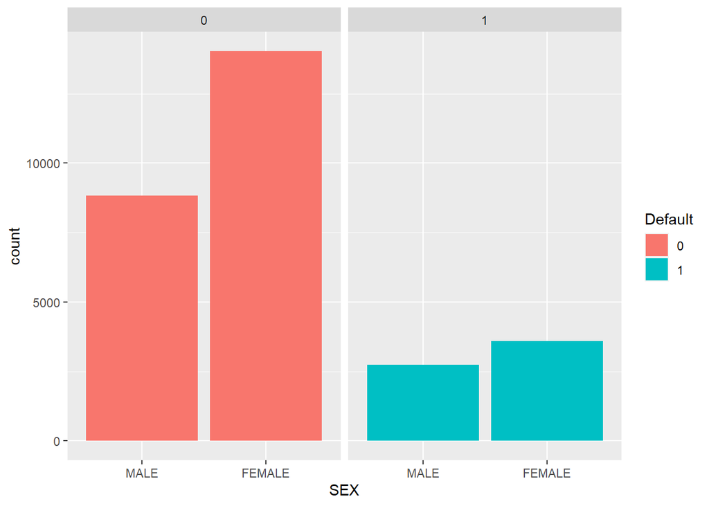

```r
ggplot(UCI_Credit_Card,aes(x=SEX,fill=as.factor(Default)))+geom_bar()+facet_wrap(~as.factor(Default))+labs(fill="Default")
```

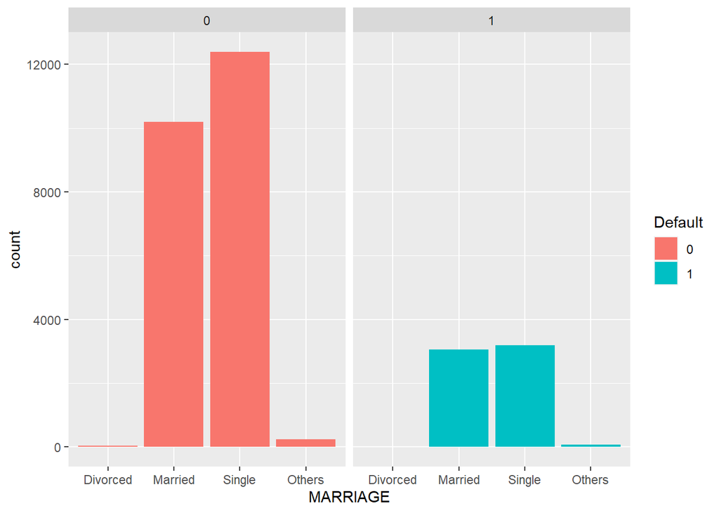

```r
ggplot(UCI_Credit_Card,aes(x=MARRIAGE,fill=as.factor(Default)))+geom_bar()+facet_wrap(~as.factor(Default))+labs(fill="Default")
```

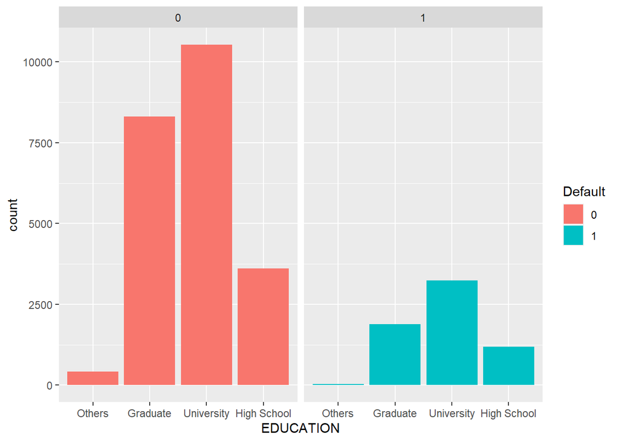

```r
ggplot(UCI_Credit_Card,aes(x=EDUCATION,fill=as.factor(Default)))+geom_bar()+facet_wrap(~as.factor(Default))+labs(fill="Default")
```

# Creating Correlation matrix for all continous independent variables with target variable

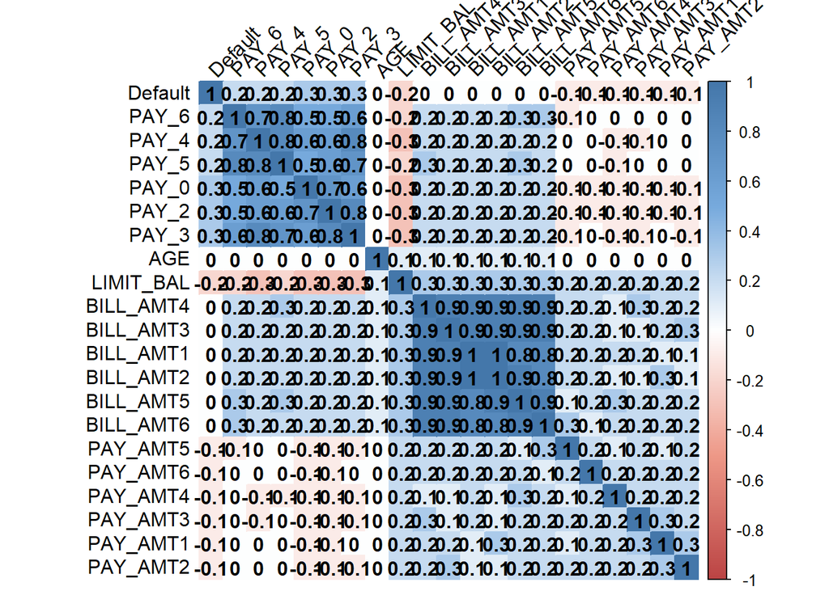

```r
UCI_Credit_Card_cor<-UCI_Credit_Card %>% select(-SEX,-EDUCATION,-MARRIAGE)
correlation_UCI_Credit_Card<-cor(UCI_Credit_Card_cor,method="pearson")
col <- colorRampPalette(c("#BB4444", "#EE9988", "#FFFFFF", "#77AADD", "#4477AA"))
corrplot(round(correlation_UCI_Credit_Card,1), method="color", col=col(200),
         type="full", order="hclust",
         addCoef.col = "black", # Add coefficient of correlation
         tl.col="black", tl.srt=45, #Text label color and rotation
         # Combine with significance
         sig.level = 0.01, insig = "blank",
         # hide correlation coefficient on the principal diagonal
         diag=TRUE
)
```

# Creating scatterplot and boxplot for LIMIT_BAL, to check for Outliers

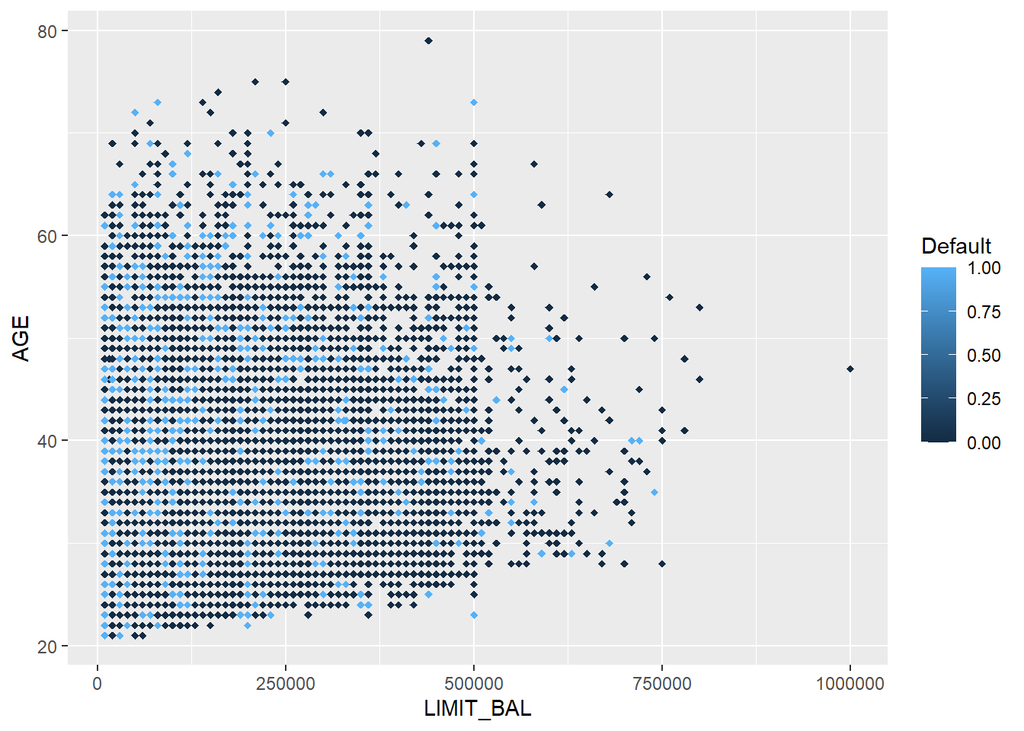

```r
ggplot(UCI_Credit_Card,aes(x=LIMIT_BAL,y=AGE,color=Default))+geom_point(shape=18)
```

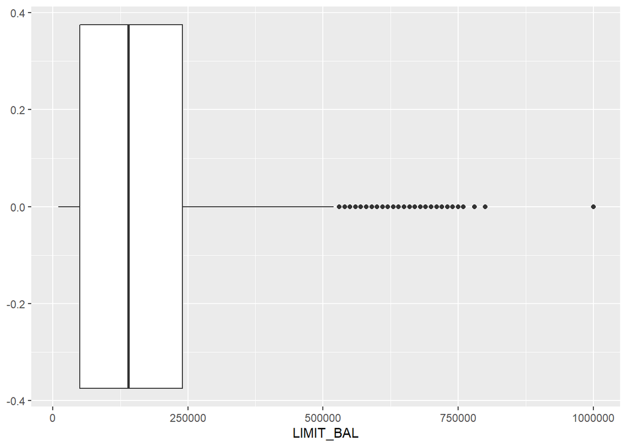

```r
ggplot(UCI_Credit_Card,aes(x=LIMIT_BAL))+geom_boxplot()
```

# Creating train and test set and create a copy of the train set to use that for Logistic Regression

```r
set.seed(1234)
split_UCI_Credit_Card <- createDataPartition(UCI_Credit_Card$Default,p=0.80,list=FALSE,times=1)
train_UCI_Credit_Card<-UCI_Credit_Card[split_UCI_Credit_Card,]
test_UCI_Credit_Card<-UCI_Credit_Card[-split_UCI_Credit_Card,]
train_UCI_Credit_Card_LR<- train_UCI_Credit_Card
```

# Create histogram for Balance Limit for train set to check data is normalized or not

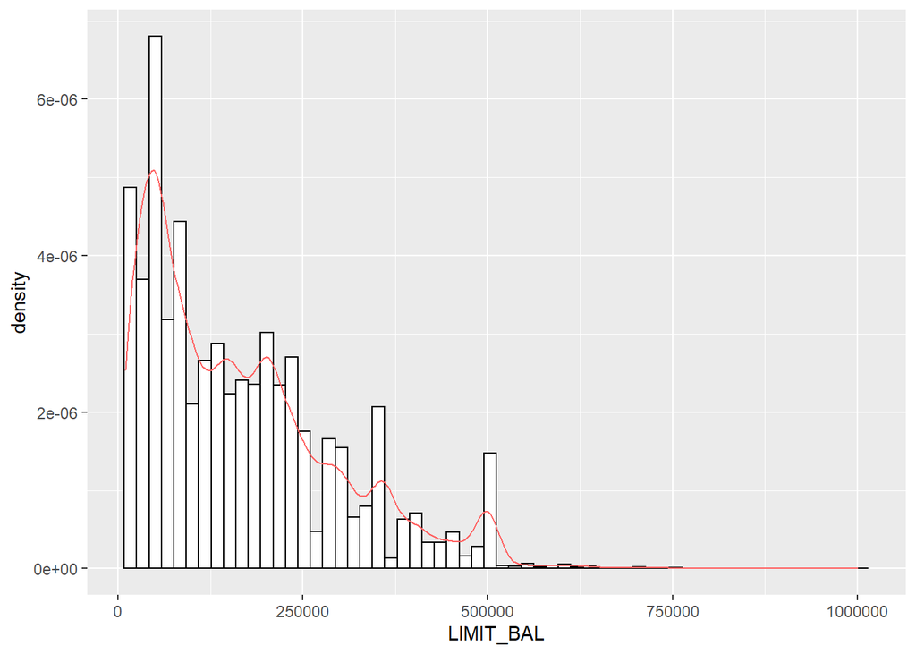

```r
ggplot(train_UCI_Credit_Card,aes(x=LIMIT_BAL))+geom_histogram(bins=60,aes(y=..density..), colour="black", fill="white")+
  geom_density(alpha=.2, color="#FF6666")
```

# Changing datatype of default variable to factor and created random forest before applying SMOTE to check if the performance will increase after SMOTE or not.

```r
train_UCI_Credit_Card$Default=as.factor(train_UCI_Credit_Card$Default)
library(randomForest)
set.seed(71)
rf <-randomForest(Default~.,data=train_UCI_Credit_Card, ntree=500)
print(rf)
```

```
##
## Call:
##  randomForest(formula = Default ~ ., data = train_UCI_Credit_Card,      ntree = 500)
##                Type of random forest: classification
##                      Number of trees: 500
## No. of variables tried at each split: 4
##
##         OOB estimate of  error rate: 17.71%
## Confusion matrix:
##       0    1 class.error
## 0 17359  980  0.05343803
## 1  3158 1863  0.62895837
```

# Checking for AUC for the Random Forest model created before SMOTE

```r
predictors <- names(train_UCI_Credit_Card)[names(train_UCI_Credit_Card)!='Default']
test_UCI_Credit_Card1<-test_UCI_Credit_Card[,predictors]
pred=(predict(rf,test_UCI_Credit_Card1,type='class'))
auc = roc( test_UCI_Credit_Card$Default,as.numeric(pred))
auc
```

```
##
## Call:
## roc.default(response = test_UCI_Credit_Card$Default, predictor = as.numeric(pred))
##
## Data: as.numeric(pred) in 4525 controls (test_UCI_Credit_Card$Default 0) < 1315 cases (test_UCI_Credit_Card$Default 1).
## Area under the curve: 0.6653
```

# Applying SMOTE to train set for Random Forest

```r
train_UCI_Credit_Card<-SMOTE(Default~.,train_UCI_Credit_Card,perc.over=200,k=10,perc.under = 180)
```

# Checking for row count and proportion for train dataset after SMOTE for Random Forest

```r
table(train_UCI_Credit_Card$Default)
```

```
##
##     0     1
## 18075 15063
```

```r
prop.table(table(train_UCI_Credit_Card$Default))
```

```
##
##         0         1
## 0.5454463 0.4545537
```

# Creating Random Forest model again with SMOTE applied train dataset and checking for AUC.

```r
set.seed(71)
rf <-randomForest(Default~.,data=train_UCI_Credit_Card, ntree=500)
print(rf)
```

```
##
## Call:
##  randomForest(formula = Default ~ ., data = train_UCI_Credit_Card,      ntree = 500)
##                Type of random forest: classification
##                      Number of trees: 500
## No. of variables tried at each split: 4
##
##         OOB estimate of  error rate: 11.27%
## Confusion matrix:
##       0     1 class.error
## 0 17115   960  0.05311203
## 1  2775 12288  0.18422625
```

```r
pred=(predict(rf,test_UCI_Credit_Card1,type='class'))
auc = roc( test_UCI_Credit_Card$Default,as.numeric(pred))
auc
```

```
##
## Call:
## roc.default(response = test_UCI_Credit_Card$Default, predictor = as.numeric(pred))
##
## Data: as.numeric(pred) in 4525 controls (test_UCI_Credit_Card$Default 0) < 1315 cases (test_UCI_Credit_Card$Default 1).
## Area under the curve: 0.6936
```

# Finding best value for hyperparameter .mtry

```
## mtry = 4  OOB error = 11.23%
## Searching left ...
## mtry = 3     OOB error = 11.49%
## -0.02229385 0.05
## Searching right ...
## mtry = 6     OOB error = 11.15%
## 0.007789417 0.05
```

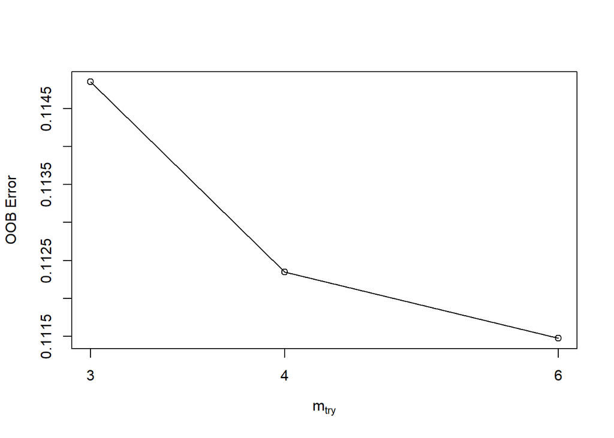

```r
mtry <- tuneRF(train_UCI_Credit_Card[-24],train_UCI_Credit_Card$Default, ntreeTry=500,
               stepFactor=1.5, trace=TRUE, plot=TRUE)
```

```r
best.m <- mtry[mtry[, 2] == min(mtry[, 2]), 1]
print(mtry)
```

```
##       mtry  OOBError
## 3.OOB    3 0.1148530
## 4.OOB    4 0.1123484
## 6.OOB    6 0.1114732
```

```r
print(best.m)
```

```
## [1] 6
```